# ggplot2 demystified - iDiv tutorial

Petr Keil

May 2, 2018

For a pretty version click [here](https://rawgit.com/petrkeil/ggplot2_demystified/master/ggplot2_demystified.html).

# 1 Introduction

This is a tutorial to basic `ggplot2` syntax and functionality. It will be used during a 1h class for PhD students and postdocs at iDiv.

The main goals are:

- To explain the basic (and unusual) `ggplot2` syntax, and to clarify terms such as `geom`, `aes`, `theme`, `stats`, `scale`.
- To give examples of the powerful `ggplot2` functionality, with special emphasis on **multivariate data**.

## 1.1 Why `ggplot2`? What is it?

- An R package for data visualization based on The Grammar of Graphics
- Created by Hadley Wickham
- Inspired by good things from both `graphics` and `lattice`
- Strong underlying model – makes things concise, consistent, readable, and flexible
- Great especially for mutlidimensional data (simulations, large observational data)
- Excellent documentation, tutorials, widespread use
- Beware: steep learning curve

## 1.2 Documentation

The best one is [here](http://ggplot2.tidyverse.org/reference/).

## 1.3 Load the library

```r
library(ggplot2)
```

## 1.4 Example data

We will use global data on **tiger beetles** from Cassola and Pearson (2000) *Biological Conservation* 95: 197-208.

```r
beetles <- read.csv("http://www.petrkeil.com/wp-content/uploads/2017/09/tiger_beetles.csv")
summary(beetles)
```

```
##       Area                S            Endemics             Country
##  Min.   :     250   Min.   :  1.0   Min.   :  0.00   Afghanistan:  1
##  1st Qu.:   76190   1st Qu.: 10.0   1st Qu.:  0.00   Albania    :  1
##  Median :  267670   Median : 19.0   Median :  1.00   Algeria    :  1
##  Mean   :  856365   Mean   : 37.6   Mean   : 10.62   Angola     :  1
##  3rd Qu.:  649970   3rd Qu.: 50.0   3rd Qu.:  7.00   Argentina  :  1
##  Max.   :17100000   Max.   :237.0   Max.   :174.00   Armenia    :  1
##                                                      (Other)    :151
##           Realm
##  Australian  : 8
##  Ethiopian   :39
##  Indian_ocean: 5
##  Nearctic    : 3
##  Neotropics  :22
##  Oriental    :27
##  Palaearctic :53
```

# 2 Basic syntax and elements

Most important things: `geom`, `aes`, `scale`, `stat`, `facet`.

## 2.1 `qplot`

`qplot` is simple to use, designed to produce easy plots, but doesn’t have the full capability.

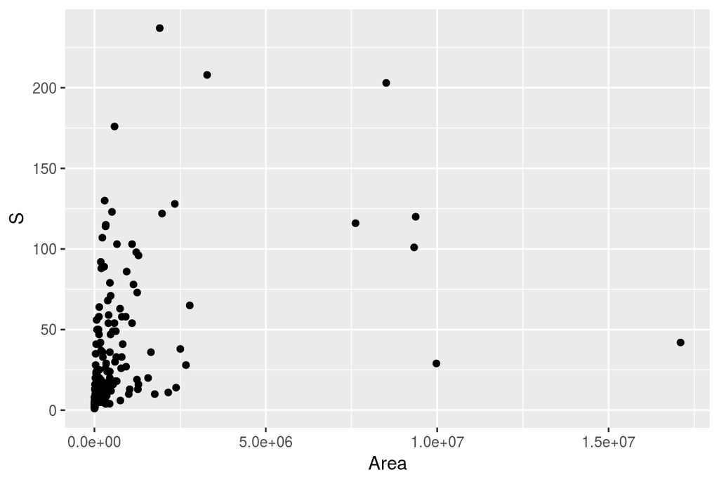

```r
qplot(x = Area, y = S, data=beetles)
```

## 2.2 `ggplot`

In the rest of the intro we will focus on `ggplot`. It’s always the same syntax:

1. Initialize `ggplot`, define data and the x and y
2. Once ggplot is intialized, add stuff (geoms, stats, scales, themes):

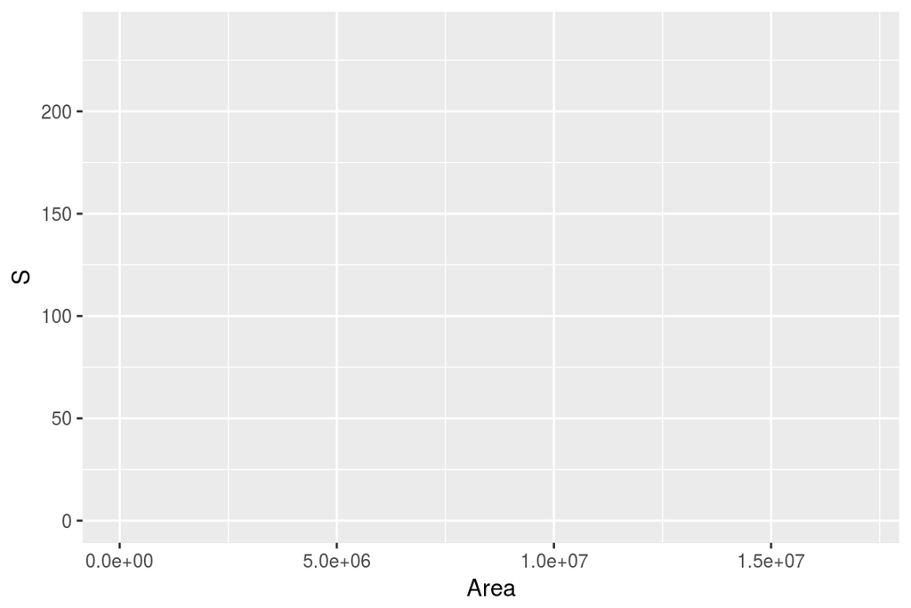

```r
p <- ggplot(data = beetles, aes(x=Area, y=S))
p
```

## 2.3 `geom`

Describes type of geometric objects to plot (points, lines, bars, …)

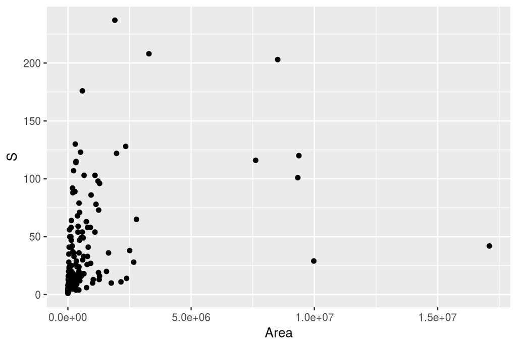

```r
p <- ggplot(data = beetles, aes(x=Area, y=S)) +
     geom_point()
p
```

## 2.4 `scale`

Describes how the data are converted to display values (log scales, color scales, …)

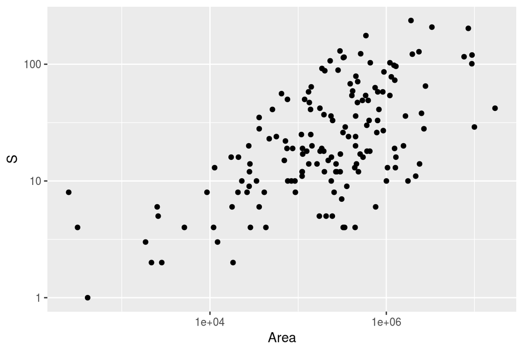

```r
p <- ggplot(data = beetles, aes(x=Area, y=S)) +
     geom_point() +
     scale_x_log10() + scale_y_log10()
p
```

## 2.5 `aes`

Describes properties of geoms that **vary** (position, colour, size, transparency)

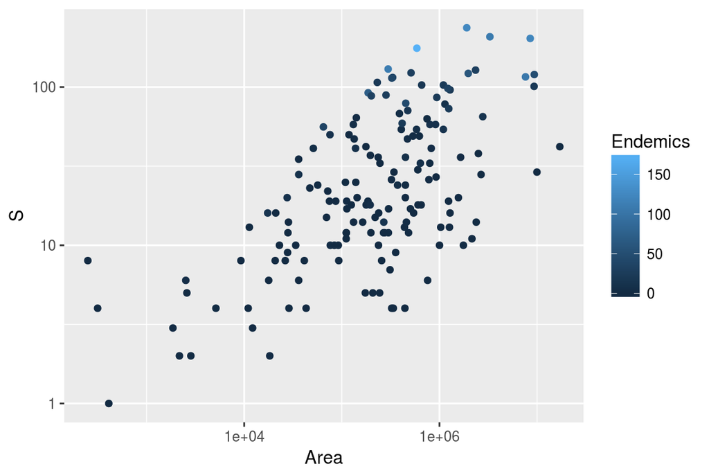

```r
p <- ggplot(data = beetles, aes(x=Area, y=S)) +
     geom_point(aes(colour = Endemics)) +
     scale_x_log10() + scale_y_log10()
p
```

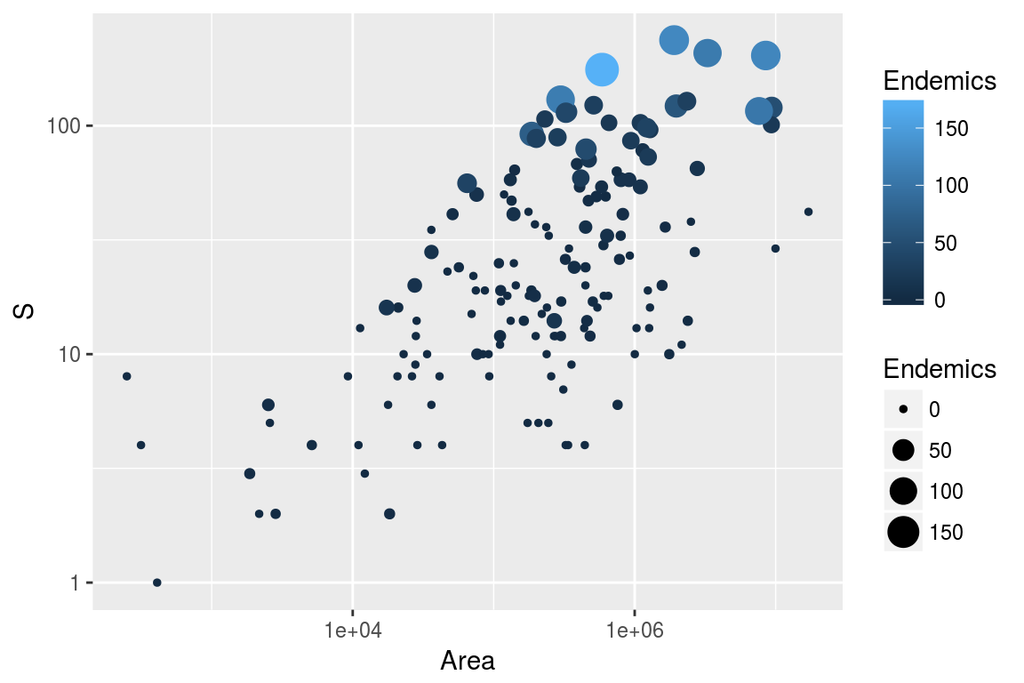

```r
p <- ggplot(data = beetles, aes(x=Area, y=S)) +
     geom_point(aes(size = Endemics, colour = Endemics)) +
     scale_x_log10() + scale_y_log10()
p
```

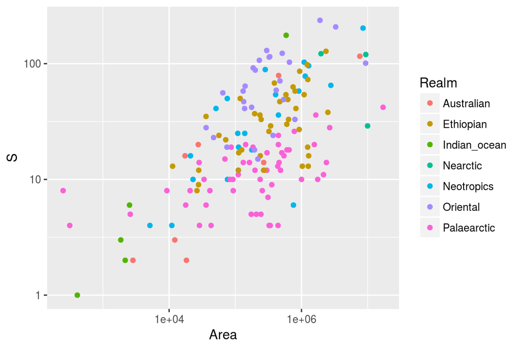

```r
p <- ggplot(data = beetles, aes(x=Area, y=S)) +
     geom_point(aes(colour = Realm)) +
     scale_x_log10() + scale_y_log10()
p
```

## 2.6 `stat`

Does statistical transformations or models (means, medians, regression lines)

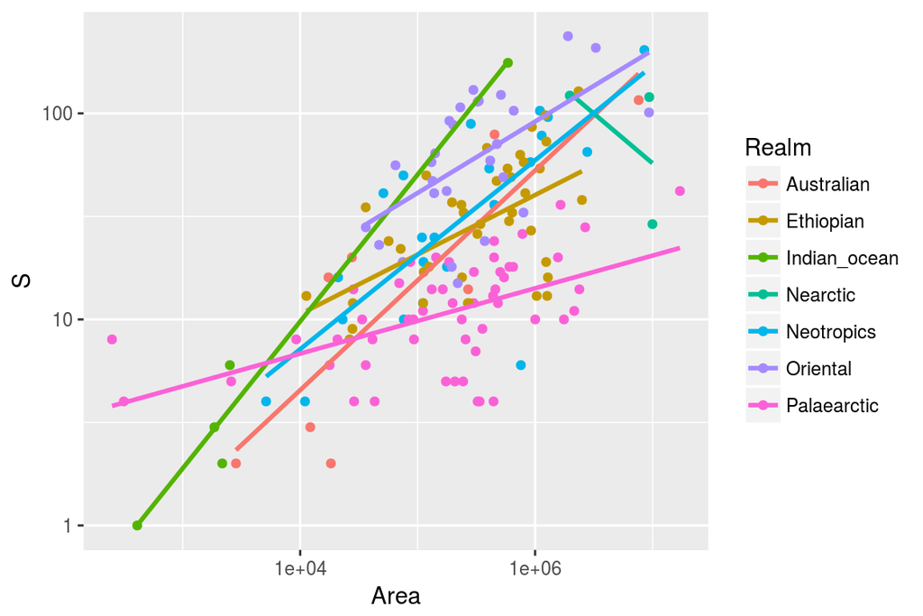

```r
p <- ggplot(data = beetles, aes(x=Area, y=S)) +
     geom_point(aes(colour = Realm)) +
     scale_x_log10() + scale_y_log10() +
     stat_smooth(aes(colour = Realm), method="lm", se=FALSE)
p
```

## 2.7 `facet`

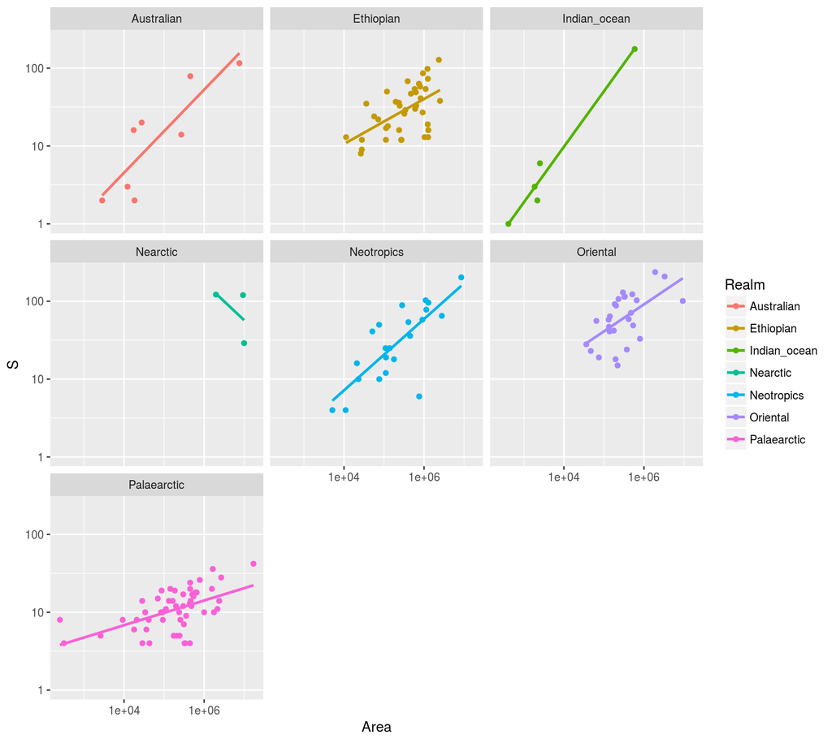

```r
p <- ggplot(data = beetles, aes(x=Area, y=S)) +
     geom_point(aes(colour = Realm)) +
     stat_smooth(aes(colour = Realm), method="lm", se=FALSE) +
     scale_x_log10() + scale_y_log10() +
     facet_wrap( ~ Realm)
p
```

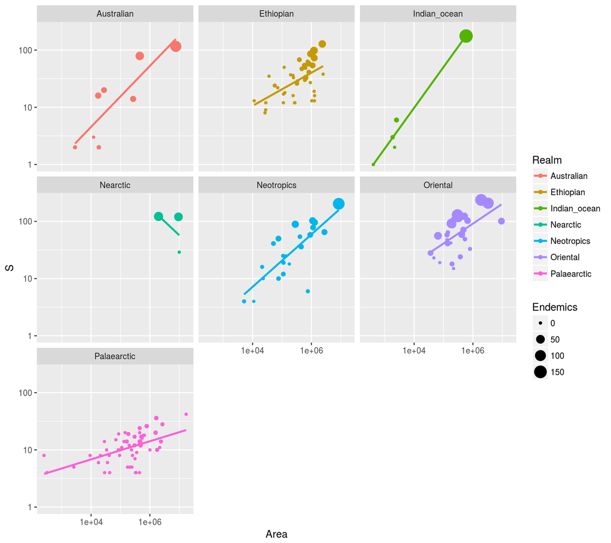

```r
p <- ggplot(data = beetles, aes(x=Area, y=S)) +
     geom_point(aes(colour = Realm, size = Endemics)) +
     stat_smooth(aes(colour = Realm), method="lm", se=FALSE) +
     scale_x_log10() + scale_y_log10() +
     facet_wrap( ~ Realm)
p
```

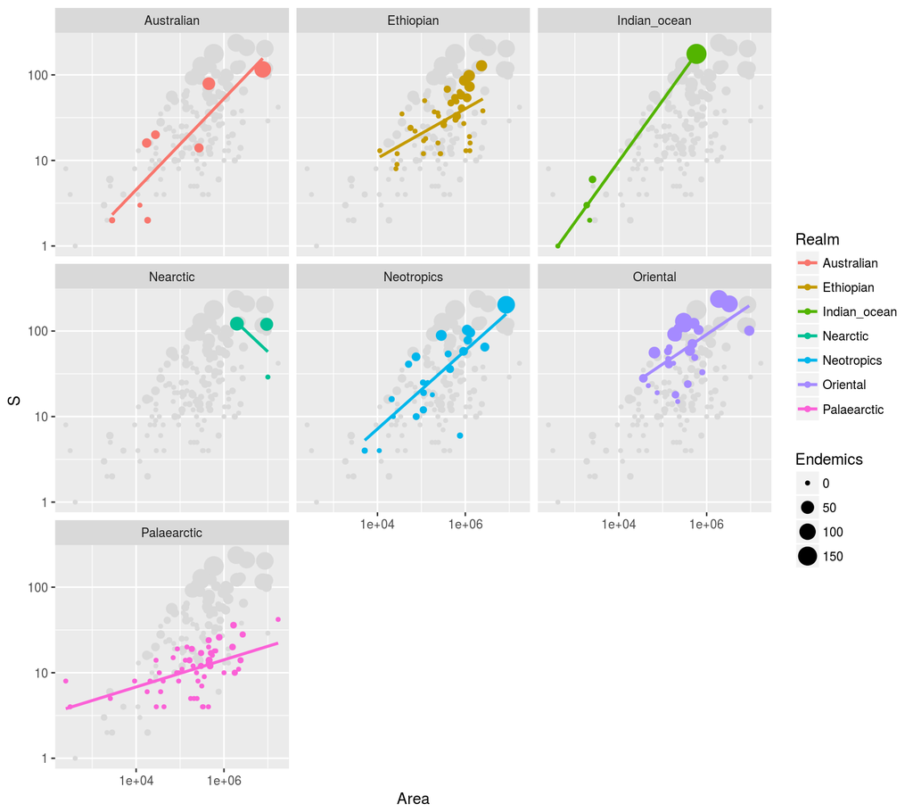

```r
p <- ggplot(data = beetles, aes(x=Area, y=S)) +
     # To repeat the same data in every panel, simply construct a data frame
     # that does not contain the facetting variable.
     geom_point(data = transform(beetles, Realm = NULL), colour = "grey85", aes(size= Endemics)) +
     geom_point(aes(colour = Realm, size = Endemics)) +
     stat_smooth(aes(colour = Realm), method="lm", se=FALSE) +
     scale_x_log10() + scale_y_log10() +
     facet_wrap( ~ Realm)
p
```

## 2.8 `theme`

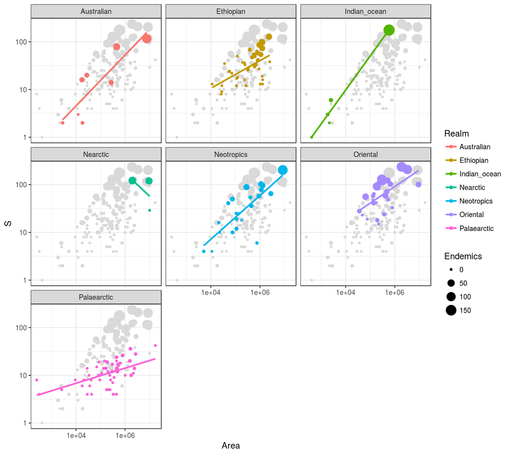

```r
p <- ggplot(data = beetles, aes(x=Area, y=S)) +
     geom_point(data = transform(beetles, Realm = NULL), colour = "grey85", aes(size= Endemics)) +
     geom_point(aes(colour = Realm, size = Endemics)) +
     stat_smooth(aes(colour = Realm), method="lm", se=FALSE) +
     scale_x_log10() + scale_y_log10() +
     facet_wrap( ~ Realm) +
     theme_bw() # try theme_classic, theme_minimal, or package ggthemes
p
```

# 3 More tricks

## 3.1 Boxplots

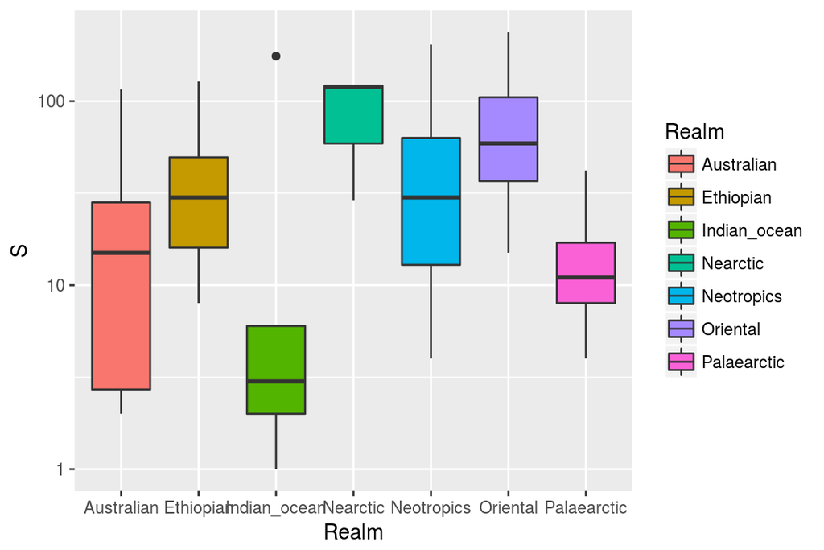

```r
p.box <- ggplot(data = beetles, aes(x=Realm, y=S)) +
         geom_boxplot(aes(fill = Realm)) +
         scale_y_log10()
p.box
```

## 3.2 Histograms

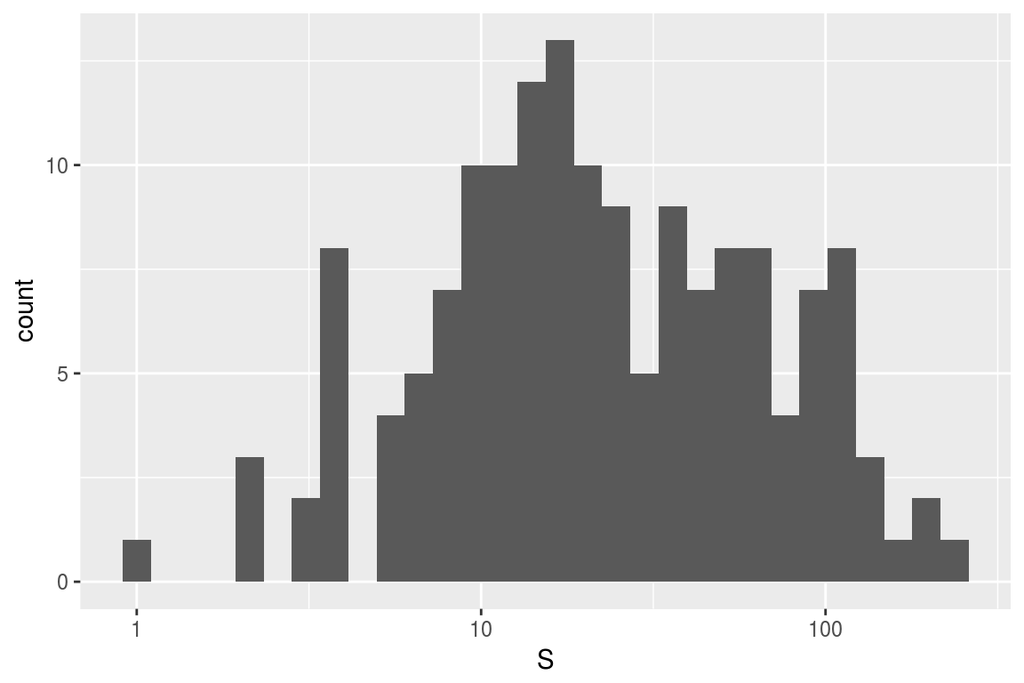

```r
p.hist <- ggplot(data = beetles, aes(x=S)) +
          geom_histogram() +
          scale_x_log10()
p.hist
```

## 3.3 Multiple panels

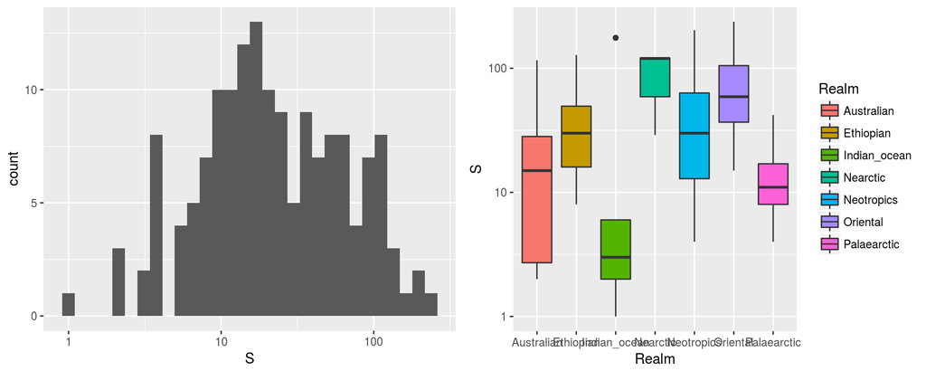

```r
library(gridExtra)
grid.arrange(p.hist, p.box, ncol=2)
```

## 3.4 Flipping coordinate systems

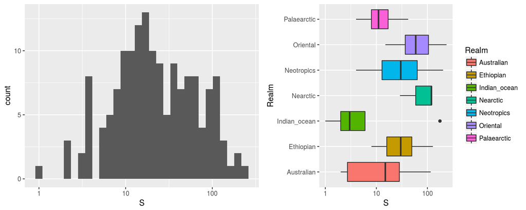

```r
grid.arrange(p.hist , p.box + coord_flip(), ncol=2)
```

## 3.5 Colour brewer

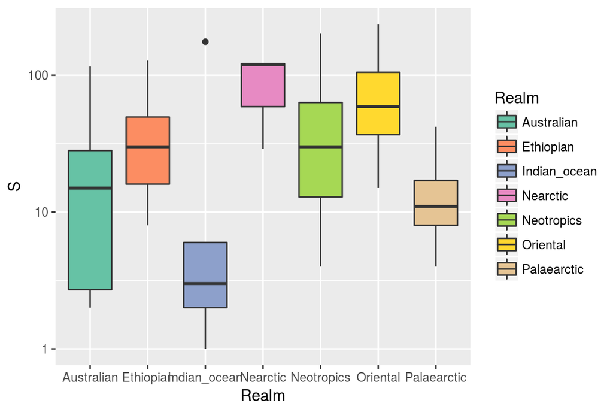

```r
p.box <- ggplot(data = beetles, aes(x=Realm, y=S)) +
         geom_boxplot(aes(fill = Realm)) +
         scale_y_log10() +
         scale_fill_brewer(palette="Set2")
p.box
```

## 3.6 Annotation

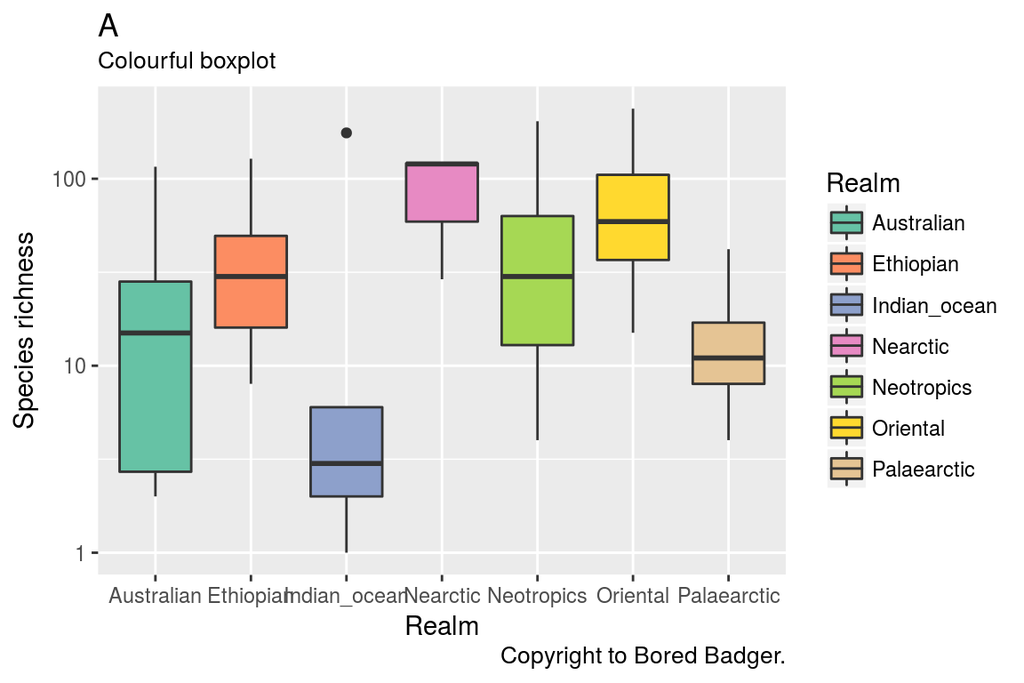

```r
p.box <- ggplot(data = beetles, aes(x=Realm, y=S)) +
         geom_boxplot(aes(fill = Realm)) +
         scale_y_log10() +
         scale_fill_brewer(palette="Set2") +
         labs(title="A",
              subtitle = "Colourful boxplot",
              y="Species richness",
              caption = "Copyright to Bored Badger.")
p.box
```